# Problem Set 1

Ananth Josyula

Due Date: 2022/09/11 @ 6PM CST

## Getting Set Up

If you haven’t already, create a folder for this course, and then a subfolder within for the third week `Topic3_HelloWorld`, and two additional subfolders within `code` and `data`.

Open `RStudio` and create a new RMarkDown file (`.Rmd`) by going to `File -> New File -> R Markdown...`. Accept defaults and save this file as `[LAST NAME]_ps1.Rmd` to your `code` folder.

Copy and paste the contents of this `Topic3_HelloWorld_PS1.Rmd` file into your `[LAST NAME]_ps1.Rmd` file. Then change the `author: [Your Name]` to your name.

If you haven’t already, download the `sc_debt.Rds` file from the course [github page](https://github.com/jbisbee1/DSCI1000/blob/main/Lectures/Topic3_HelloWorld/data/sc_debt.Rds) and save it to your `data` folder.

All of the following questions should be answered using

````
```{r}
# EXAMPLE CODE
mean(c(1,2,3))
```
````

Some questions will also ask for answers written out in English, instead of just `R` code. These will be indicated with the code

```
> - Write answer here
```

This problem set is worth 20 total points, plus one extra credit point. The point values for each question are indicated in brackets below. You are free to rely on whatever resources you need to complete this problem set, including lecture notes, lecture presentations, Google, your classmates…you name it. However, the final submission must be complete by you. There are no group assignments. To submit, compiled the completed problem set and upload the `.html` file to Brightspace by 6PM CST on 2022/09/11.

**Good luck!**

## Question 1 [1 point]

*Require `tidyverse` and load the `sc_debt.Rds` data by assigning it to an object named `df`.*

```r
# INSERT CODE HERE
require(tidyverse)
df<-readRDS("../data/sc_debt.Rds")
```

## Question 2 [2 points]

*Which school has the lowest admission rate?*

```r
# INSERT CODE HERE
df %>%
  arrange(adm_rate) %>%
  select(instnm,adm_rate)
```

```
## # A tibble: 2,546 × 2
##    instnm                                      adm_rate
##    <chr>                                          <dbl>
##  1 Saint Elizabeth College of Nursing            0
##  2 Yeshivat Hechal Shemuel                       0
##  3 Hampshire College                             0.0197
##  4 Curtis Institute of Music                     0.0393
##  5 Stanford University                           0.0434
##  6 Harvard University                            0.0464
##  7 Pacific Oaks College                          0.0511
##  8 Columbia University in the City of New York   0.0545
##  9 Princeton University                          0.0578
## 10 Yale University                               0.0608
## # … with 2,536 more rows
```

> - Saint Elizabeth College of Nursing has the lowest admission rate. It is tied with Yeshivat Hechal Shemuel for an admission rate of 0

## Question 3 [2 points]

*Which are the top 10 schools by average SAT score?*

```r
# INSERT CODE HERE
df %>%
  arrange(-sat_avg) %>%
  select(instnm,sat_avg)
```

```
## # A tibble: 2,546 × 2
##    instnm                                 sat_avg
##    <chr>                                    <int>
##  1 California Institute of Technology        1557
##  2 Massachusetts Institute of Technology     1547
##  3 University of Chicago                     1528
##  4 Harvey Mudd College                       1526
##  5 Duke University                           1522
##  6 Franklin W Olin College of Engineering    1522
##  7 Washington University in St Louis         1520
##  8 Rice University                           1520
##  9 Yale University                           1517
## 10 Harvard University                        1517
## # … with 2,536 more rows
```

> - The top 10 schools by average SAT score are: California Institute of Technology, Massachusetts Institute of Technology, University of Chicago, Harvey Mudd College, Duke University, Franklin W Olin College of Engineering, Washington University in St Louis, Rice University, Yale University, Harvard University

## Question 4 [2 points]

*Which state is home to the school with the largest median earnings of recent graduates, and how much did they make?*

```r
# INSERT CODE HERE
df %>%
  arrange(-md_earn_wne_p6) %>%
  select(instnm,stabbr,md_earn_wne_p6)
```

```
## # A tibble: 2,546 × 3
##    instnm                                                       stabbr md_earn…¹
##    <chr>                                                        <chr>      <int>
##  1 University of Health Sciences and Pharmacy in St. Louis      MO        120400
##  2 Albany College of Pharmacy and Health Sciences               NY        112100
##  3 Samuel Merritt University                                    CA        100100
##  4 Massachusetts Institute of Technology                        MA         82200
##  5 Oregon Health & Science University                           OR         80000
##  6 Louisiana State University Health Sciences Center-Shreveport LA         78200
##  7 Cochran School of Nursing                                    NY         77300
##  8 Duke University                                              NC         76300
##  9 MCPHS University                                             MA         75700
## 10 Los Angeles County College of Nursing and Allied Health      CA         75300
## # … with 2,536 more rows, and abbreviated variable name ¹md_earn_wne_p6
```

> - MO is the state with the largest median earnings of recent graduates. Those graduating from University of Health Sciences and Pharmacy in St. Louis made 120400

## Question 5 [2 points]

*What is the average SAT score of the school with the highest median earnings identified in question 3?*

```r
# INSERT CODE HERE
df %>%
  filter(instnm == "University of Health Sciences and Pharmacy in St. Louis") %>%
  select(instnm,stabbr,sat_avg)
```

```
## # A tibble: 1 × 3
##   instnm                                                  stabbr sat_avg
##   <chr>                                                   <chr>    <int>
## 1 University of Health Sciences and Pharmacy in St. Louis MO        1262
```

> - The average SAT score of University of Health Sciences and Pharmacy in St. Louis is 1262

## Question 6 [2 points]

*Calculate the average SAT score and median earnings of recent graduates by state.*

```r
# INSERT CODE HERE
df %>%
  group_by(stabbr) %>%
  summarise(mean_sat = mean(sat_avg,na.rm=T),mean_earning = mean(md_earn_wne_p6, na.rm=T))
```

```
## # A tibble: 51 × 3
##    stabbr mean_sat mean_earning
##    <chr>     <dbl>        <dbl>
##  1 AK        1121        33300
##  2 AL        1123.       28082.
##  3 AR        1141.       30452.
##  4 AZ        1147.       27613.
##  5 CA        1183.       33017.
##  6 CO        1132.       33955.
##  7 CT        1194.       35994.
##  8 DC        1262        41325
##  9 DE        1043        32443.
## 10 FL        1142.       30318.
## # … with 41 more rows
```

## Question 7 [2 points]

*Plot the average SAT score (x-axis) against the median earnings of recent graduates (y-axis) by school.*

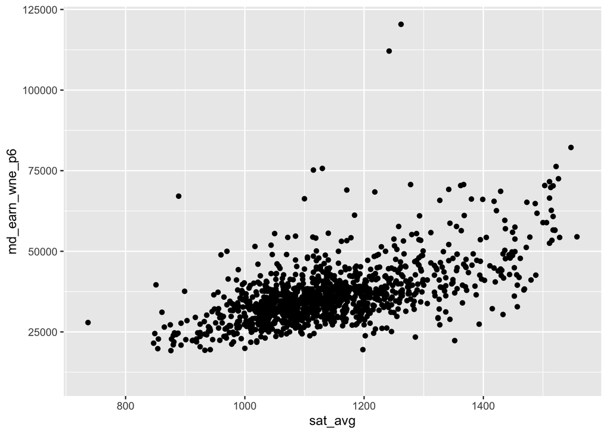

```r
# INSERT CODE HERE
df %>%
  ggplot(aes(x = sat_avg,y = md_earn_wne_p6)) +
  geom_point()
```

## Question 8 [4 points]

*Plot the average SAT score (x-axis) against the median earnings of recent graduates (y-axis) by **STATE**. (Extra credit: plot the line of best fit.)*

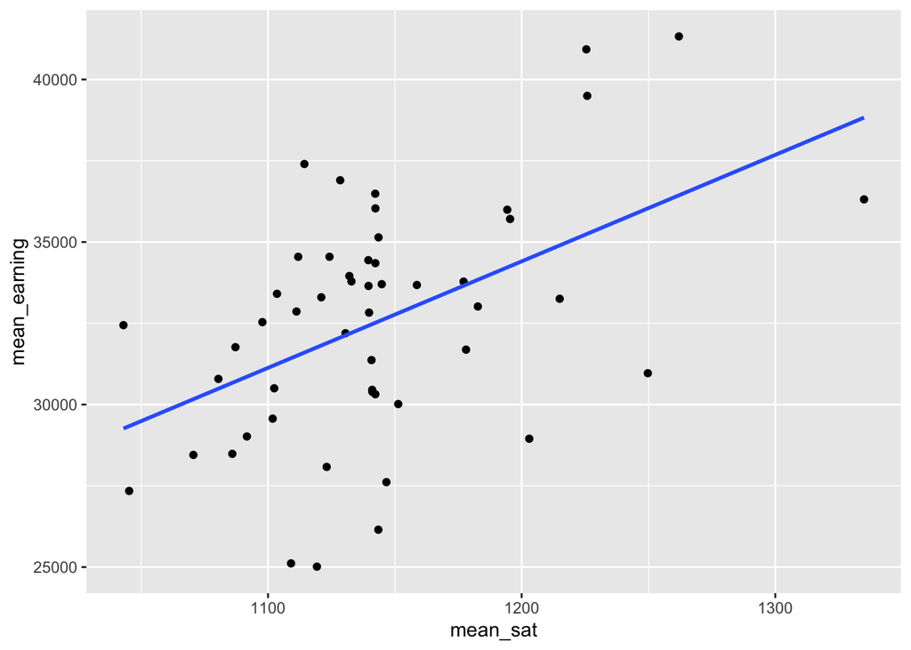

```r
# INSERT CODE HERE
df %>%
  group_by(stabbr) %>%
  summarise(mean_sat = mean(sat_avg,na.rm=T), mean_earning = mean(md_earn_wne_p6, na.rm=T)) %>%
  ggplot(aes(x = mean_sat,y = mean_earning)) +
  geom_point() +
  geom_smooth(method = 'lm',se = F)
```

## Question 9 [4 points]

*What relationship do you observe? Why do you think this relationship exists?*

> - I observe a positive correlation between the average SAT score and the median earnings of recent graduates by state. This means that as states’ average SAT scores increase, the median earnings of that state’s recent graduates also rises. This could be because students who score higher on the SAT are more likely to attend prestigious institutions that provide better exposure to recruiters who pay higher salaries to recent graduates.